# Previsione morti COVID-19 per la Lombardia per il periodo dal 1 gennaio al 31 marzo 2020

Laura Cavenati, Lorenzo Mauri, Marco Distrutti

06 maggio 2020

Ultimamente si sente dire spesso che il numero di decessi dovuti al COVID-19 in Italia sia di molto superiore ai dati forniti giornalmente dalla protezione civile. Con questo lavoro cercheremo di dare una stima ragionevole dei morti COVID-19 a partire dai dati relativi al numero effettivo di decessi avvenuti in Italia fino al 31 Marzo 2020 secondo l’Istat. Purtroppo i dati Istat non costituiscono un campione rappresentativo dell’universo dei comuni italiani, ma solo un loro sottoinsieme meritevole di attenzione. L’Istat ha scelto, infatti, di concentrare l’attenzione sui comuni presenti in ANPR (Anagrafe Nazionale Popolazione Residente), con dati affidabili, che presentano almeno dieci decessi nel periodo 4 gennaio - 4 aprile 2020 e che hanno registrato un aumento dei morti pari o superiore al 20 per cento nel periodo 1 marzo-4 aprile 2020 rispetto al dato medio dello stesso periodo degli anni 2015-2019. Per un’analisi più dettagliata delle caratteristiche dei comuni considerati, si rimanda al sito: https://www.istat.it/it/archivio/240401

Noi ci concentreremo sul periodo 1 gennaio- 31 marzo perchè i dati relativi ad aprile non sono ancora affidabili e completi.

Inoltre, a nostro parere, a partire da questi dati, è piuttosto difficile, se non impossibile, stimare solo i morti direttamente correlati a patologie legate all’infezione da COVID. Infatti, nel periodo considerato, gennaio-marzo, a causa delle restrizioni del governo e della quarantena, il numero di decessi per tutte le cause è fortemente cambiato rispetto allo stesso periodo degli anni precedenti. Si pensi solo al calo dei morti per incidenti stradali e sul lavoro, all’aumento dei decessi domestici, o ancora al probabile aumento dei decessi di pazienti non COVID causati dalla difficoltà di accesso al servizio sanitario o dall’impossibilità del servizio sanitario a far fronte a tutte le richieste in momenti di forte stress. Perciò la nostra stima riguarderà il numero dei decessi in qualche modo relazionatial COVID.

Organizziamo, puliamo e sistemiamo i diversi dataset in modo che i dati siano ben organizzati per rispondere alla nostra domanda.

```r
#sistemo il dataset in modo che i dati siano ben organizzati
pop %>%  rename( COD_PROVCOM = ï..ITTER107, ABITANTI = Value )%>%
        filter(Sesso=="totale")%>%
        select(-c(Territorio:Seleziona.periodo ,Flag.Codes,Flags))%>%
        mutate(COD_PROVCOM=as.character(COD_PROVCOM))%>%
        mutate(COD_PROVCOM=as.numeric(COD_PROVCOM))->pop

pop <- na.omit(pop)
#ci sono alcune righe che non rappresentano comuni ma regioni e aree geografiche, quindi le tolgo.

#Sistemo il dataframe in modo che sia più funzionale, come abbiamo fatto a lezione
td %>% gather(key="SESSO_ANNO", value="DECESSI", MASCHI_15:TOTALE_20)%>%
      separate(SESSO_ANNO, c("SESSO", "ANNO"), "_")%>%
      mutate(DATA = as.Date(paste0("0", GE, "2020"), format = "%m%d%Y")) -> td

#Faccio una join con pop così aggiungo la colonna con il numero di abitanti per comune
td<-left_join(td, pop, by="COD_PROVCOM")

#Escono dei NAN che sono dovuti al fatto che i due diversi dataframe sono aggiornati a date diverse;
#pop è aggornato al 01/01/2019, td al 04/04/2020. In questo lasso di
#tempo alcuni comuni si sono fusi tra di loro, ne sono nati altri...
td <- na.omit(td)
```

Facciamo una prima analisi esplorativa del dataset per determinare di quanti comuni Istat fornisce i dati relativi al primo trimestre del 2020 e come viene indicata la mancanza di dati. Istat in una nota afferma che: “il valore 9999 indica che il valore nel 2020 non è ancora disponibile. I comuni con dati presenti nell’anno 2020 sono 1.689”.

```r
#non ci sono valori non disponibili nei mesi gennaio-marzo per i comuni di cui abbiamo i dati del 2020
td %>%   filter(DATA_INIZIO_DIFF!="Dati 2020 n.d.", format(as.Date(DATA), "%m")!="04", DECESSI==9999)%>%
  count()->valnondisp
as.numeric(valnondisp)
```

```
## [1] 0
```

Altra nota  
La variabile DATA_INIZIO_DIFF indica la data in cui il comune ha iniziato a soddisfare le richieste (numero di decessi > 10 nell’ultimo trimestre e incremento della mortalità >20% rispetto al dato medio dello stesso periodo degli anni 2015-2019) ed è entrato quindi a far parte dei comuni analizzati (ci sono tre diverse date di rilascio).

```r
levels(td$DATA_INIZIO_DIFF)
```

```
## [1] "1 aprile"       "16 aprile"      "8 aprile"       "Dati 2020 n.d."
```

Ad ogni rilascio, i nuovi comuni che rispettano i criteri di selezione si aggiungono ai precedenti. Nel dataset però sono presenti tutti i comuni italiani. Per quelli che non soddisfano le richieste, Istat ha considerato DATA_INIZIO_DIFF=“Dati 2020 n.d.” e ha posto il valore 9999 come numero di morti per tutte le date del 2020 (per questi comuni, per gli anni precedenti i dati sono disponibili). Quando analizzeremo i morti del 2020 considereremo quindi solo i comuni con DATA_INIZIO_DIFF diversa da “Dati 2020 n.d.”.

```r
td %>% select(-c(REG, PROV, CL_ETA,GE))%>%
      filter(SESSO=="TOTALE", DECESSI<9999, format(as.Date(DATA), "%m")!="04" )%>%
      group_by(ANNO, NOME_REGIONE, COD_PROVCOM, NOME_PROVINCIA, DATA_INIZIO_DIFF, ABITANTI, DATA)%>%
      summarise(DECESSI=sum(DECESSI))->tdp
```

Per avere un’idea della bontà della copertura dei dati Istat, andiamo a vedere la percentuale di popolazione, relativa alle diverse regioni, di cui Istat ci ha fornito i dati e la percentuale di popolazione che rientra nei comuni considerati dall’ANPR. Il file che riporta i comuni subentrati in ANPR che abbiamo utilizzato è disponibile al link: https://www.anpr.interno.it/portale/tabelle-di-riferimento

```r
ANPR %>% mutate(DATASUBENTRO=as.character(ANPR$DATASUBENTRO))%>%
        mutate(DATASUBENTRO=as.Date.character(ANPR$DATASUBENTRO,"%d/%m/%Y"))%>%
        mutate(diffDate=as.numeric(as.Date("2019-12-31")-ANPR$DATASUBENTRO))->ANPR

#considero solo i comuni che fanno parte dei comuni in ANPR in data 31/12/2019 perchè Istat afferma di considerare solo questi comuni.
ANPR %>% select(CODISTAT, DATASUBENTRO, diffDate)%>%
        filter(diffDate>0)%>%
        select(-c(diffDate,DATASUBENTRO))%>%
        rename(COD_PROVCOM=CODISTAT)->ANPR

#dataframe con abitanti per comune, COD_PROVCOM e relativa regione di appartenenza
td %>% distinct(NOME_REGIONE,COD_PROVCOM, ABITANTI)%>%
      group_by(COD_PROVCOM, ABITANTI)->AbitantiPerComune

left_join(ANPR, AbitantiPerComune, by="COD_PROVCOM")->ANPR

#Non ho la regione di tutti i comuni perchè i dataframe non sono aggiornati alla stessa data. Considero quindi questi comuni come se non rientrassero in ANPR
ANPR <- na.omit(ANPR)

#popolazione per regione coperta dall'ANPR
ANPR %>% group_by(NOME_REGIONE)%>%
        summarise(abitantiANPR=sum(ABITANTI))->ANPR

#abitanti per regione che rientrano nei comuni in ANPR
td %>% distinct(NOME_REGIONE, COD_PROVCOM, ABITANTI)%>%
      group_by(NOME_REGIONE)%>%
      summarise(abitanti=sum(ABITANTI))->AbitantiPerRegione

inner_join(AbitantiPerRegione, ANPR, by="NOME_REGIONE")->ANPR

#abitanti per regione che rientrano nei comuni considerati dall'Istat
td %>% filter(DATA_INIZIO_DIFF!="Dati 2020 n.d." )%>%
      distinct(COD_PROVCOM, NOME_REGIONE, ABITANTI)%>%
      group_by(NOME_REGIONE)%>%
      summarise(abitantiCampionati=sum(ABITANTI))->AbitantiPerRegioneCampionati

inner_join( ANPR, AbitantiPerRegioneCampionati, by="NOME_REGIONE")->TOT

#dataframe riassuntivo che compara le varie percentuali per regione
TOT %>% mutate(percANPR=abitantiANPR/abitanti*100,percCAMPIONATI=abitantiCampionati/abitanti*100)->TOT
TOT
```

| NOME_REGIONE | abitanti | abitantiANPR | abitantiCampionati | percANPR | percCAMPIONATI |
| --- | --- | --- | --- | --- | --- |
| Abruzzo | 1311580 | 968853 | 170540 | 73.86915 | 13.002638 |
| Basilicata | 562869 | 287820 | 46649 | 51.13446 | 8.287719 |
| Calabria | 1947131 | 832290 | 98955 | 42.74443 | 5.082093 |
| Campania | 5801692 | 3437648 | 258209 | 59.25251 | 4.450581 |
| Emilia-Romagna | 4459477 | 4068196 | 2718973 | 91.22585 | 60.970670 |
| Friuli-Venezia Giulia | 1215220 | 550656 | 118647 | 45.31328 | 9.763417 |
| Lazio | 5879082 | 2116953 | 184596 | 36.00822 | 3.139878 |
| Liguria | 1550640 | 1339486 | 1071658 | 86.38278 | 69.110690 |
| Lombardia | 10051747 | 8873792 | 7262054 | 88.28109 | 72.246685 |
| Marche | 1525271 | 952465 | 513284 | 62.44562 | 33.651987 |

[output cut: 10 more lines]

I comuni monitorati dall’Istat sono un sottoinsieme di quelli che hanno aderito all’ANPR, la cui copertura, in termini di popolazione, è mostrata nella tabella.  
percANPR indica la percentuale della popolazione, per regione, che rientra nei comuni in ANPR, percCAMPIONATI indica la percentuale della popolazione, per regione, che rientra nei comuni campionati dall’Istat. Come si vede, la copertura dei dati dell’Istat è tale da non permettere stime significative in molte regioni italiane (soprattutto quelle del sud, come Campania e Basilicata dove ci sono stati anche meno decessi dovuti al virus).

Al fine di ridurre il bias preferiamo quindi concentrarci solo la Lombardia, il cui campionamento messo a disposizione dall’Istat costituisce una buona copertura del totale. Come mostra la tabella, la percentuale della popolazione considerata dall’Istat è il 72% della popolazione totale della Lombardia, mentre quella che rientra nei comuni in ANPR è 88%. La domanda finale a cui vogliamo rispondere è quindi: “QUANTI SONO STATI I DECESSI RELAZIONATI A COVID-19 IN LOMBARDIA NEL PERIODO DAL 1 GENNAIO AL 31 MARZO 2020?”

Come prima cosa andiamo a fare un’analisi grafica delle serie storiche dei decessi (per i comuni di cui Istat ci ha fornito i dati) in Lombardia e in ogni sua provincia.

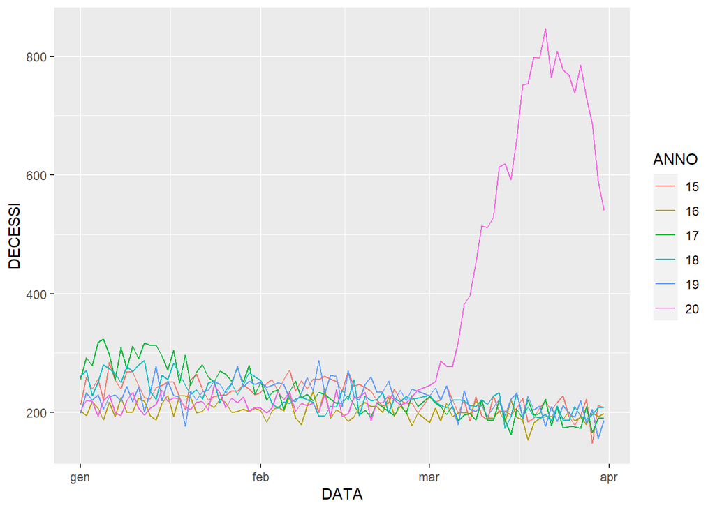

```r
  tdp %>% filter(DATA_INIZIO_DIFF!="Dati 2020 n.d.",NOME_REGIONE == "Lombardia",as.Date(DATA)!=as.Date("2020-02-29"))%>%
        group_by(DATA, ANNO, NOME_PROVINCIA) %>%
        summarise(DECESSI = sum(DECESSI)) %>%
        arrange(ANNO, DATA) %>%
        ungroup() -> tdpp

tdpp %>% group_by(DATA, ANNO) %>%
          summarise(DECESSI = sum(DECESSI)) %>%
          ggplot(aes(x = DATA, y = DECESSI, color = ANNO)) +geom_line()
```

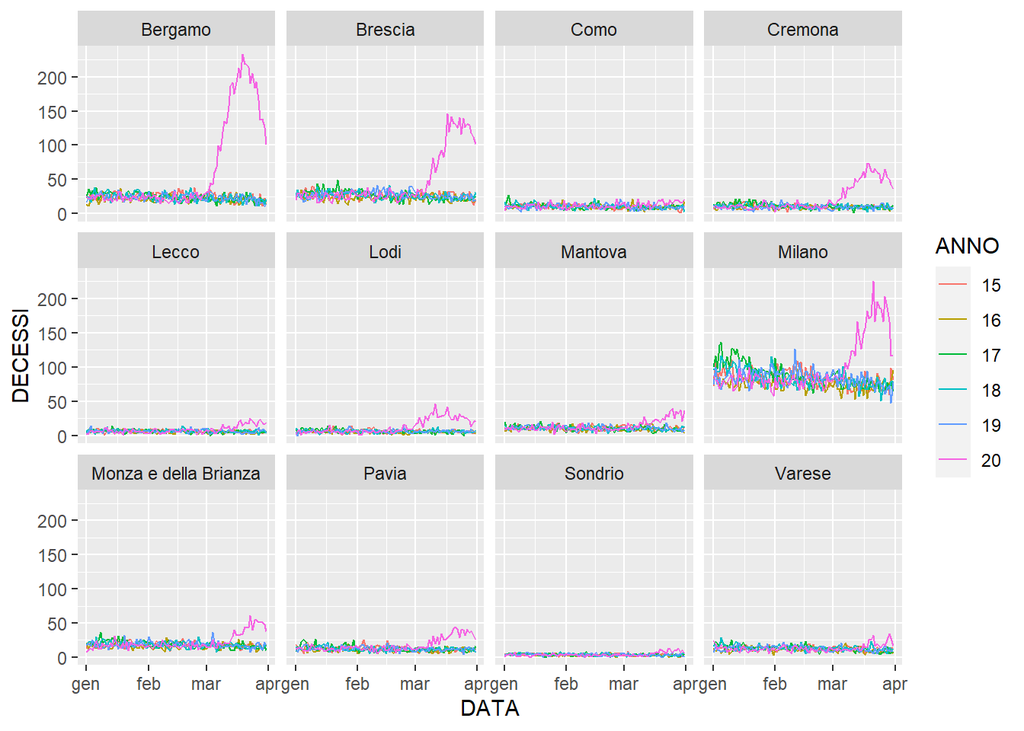

```r
tdpp %>% ggplot(aes(x = DATA, y = DECESSI, color = ANNO)) +  geom_line() +
  facet_wrap(~NOME_PROVINCIA)
```

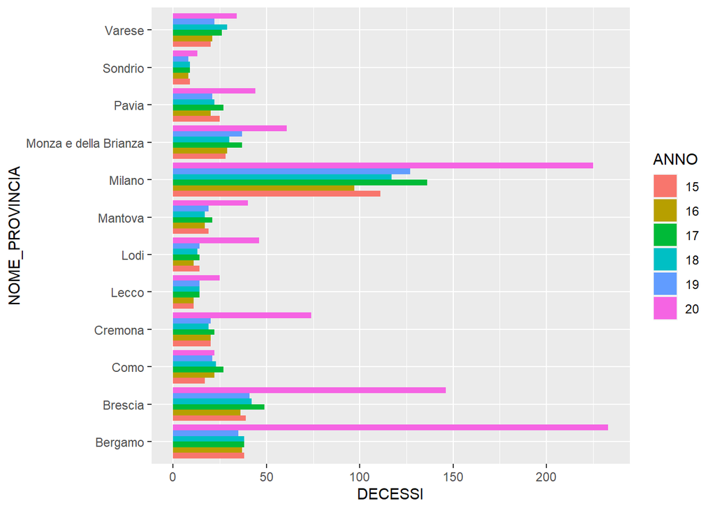

```r
tdpp %>% ggplot(aes(x = NOME_PROVINCIA, y = DECESSI, fill = ANNO)) +
       geom_bar(stat = "identity",position=position_dodge()) + coord_flip()
```

Gli andamenti dei decessi per le province di Bergamo, Brescia e Milano sono particolarmente significativi.

```r
tdp %>% filter(NOME_REGIONE=="Lombardia")->tdpl
TOT %>%  filter(NOME_REGIONE=="Lombardia")->Lombardia
```

Per stimare i morti dovuti al COVID-19 abbiamo deciso di non considerare come base di riferimento la media stagionale dei morti negli anni 2015-2019 perchè, come si vede dal grafico, nel periodo gennaio-febbraio 2020, ci sono state meno morti rispetto agli anni precedenti. Ciò potrebbe essere dovuto al fatto che l’inverno 2019-2020 è stato tra i più caldi degli ultimi 100 anni e quindi le morti dovute alle infezioni stagionali (non COVID) potrebbero essere state inferiori. Le statistiche dell’Istituto di scienze dell’atmosfera e del clima del Cnr di Bologna infatti affermano che l’inverno appena trascorso, ha fatto registrare in Italia un’anomalia di 2,03°C al di sopra della media stagionale relativa al trentennio 1981-2010. Assumiamo quindi che il numero di morti per il 2020, escludendo i decessi causati dal COVID-19, sia pari a quello del 2016 che, come notiamo dal grafico, ha avuto un andamento simile al 2020 nel periodo gennaio-febbraio. Per trovare il numero di morti COVID-19 quindi sottraiamo al totale dei morti del 2020 quelli del 2016 nei primi tre mesi dell’anno.

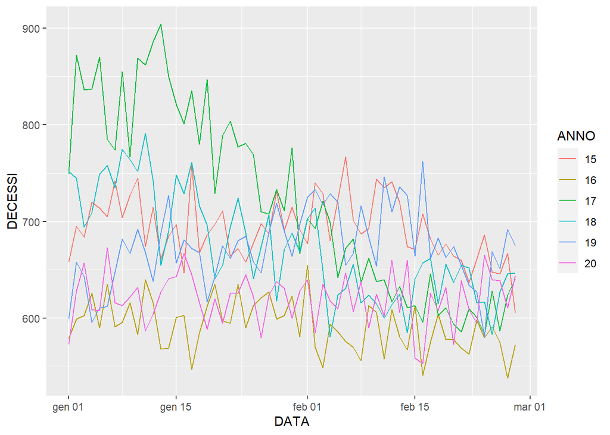

```r
tdp%>%  filter(DATA_INIZIO_DIFF!="Dati 2020 n.d.",format(as.Date(DATA), "%m")!="03",as.Date(DATA)!=as.Date("2020-02-29"))%>%
        group_by(DATA, ANNO) %>%
        summarise(DECESSI = sum(DECESSI))%>%
        arrange(ANNO, DATA) %>%
        ungroup()->tdpg

tdpg %>% ggplot(aes(x = DATA, y = DECESSI, color = ANNO)) + geom_line()
```

Per fare una stima dei morti COVID-19, dato che non abbiamo tutti i comuni ma solo un campione non casuale, possiamo calcolare i morti relazionati COVID-19 per i comuni di cui abbiamo i dati dall’Istat. Per i comuni non considerati dall’Istat ma che rientrano nei comuni in ANPR, possiamo fare una stima, considerando come limite inferiore che non ci siano stati morti COVID-19, e come limite superiore che la mortalità per COVID-19 sia stata pari a quella dei comuni campionati. Ipotizziamo inoltre che il fatto di rientrare o meno tra i comuni in ANPR non sia correlata al numero dei decessi in eccesso; consideriamo quindi che i comuni non ANPR abbiano avuto una mortalità per COVID-19 pari a quella media dei comuni analizzati dall’Istat. Per stimare i morti in questi comuni moltiplichiamo la popoplazione non ANPR per la mortalità media registrata nel complesso nei comuni ANPR della Lombardia.

```r
tdpl %>% filter(DATA_INIZIO_DIFF!="Dati 2020 n.d.")%>%
        group_by(ANNO)%>%
        summarise(DECESSIperanno=sum(DECESSI))->tdplc

#morti per COVID-19 nei comuni campionati dall'Istat
mortiLombardiaCampionata<-tdplc$DECESSIperanno[6]-tdplc$DECESSIperanno[2]

#limite superiore dei morti per COVID-19 nei comuni non campionati dall'Istat
mortiLombardiaNonCampionatasup<-mortiLombardiaCampionata/Lombardia$abitantiCampionati*(Lombardia$abitantiANPR-Lombardia$abitantiCampionati)

#limite superiore e inferiore dei morti per COVID-19 nei comuni non in ANPR (pari a popolazione non in ANPR * mortalità COVID-19 nei comuni campionati dall'Istat)
mortiLombardiaNonANPRinf<-(Lombardia$abitanti-Lombardia$abitantiANPR)*((mortiLombardiaCampionata)/Lombardia$abitantiANPR)
mortiLombardiaNonANPRsup<-(Lombardia$abitanti-Lombardia$abitantiANPR)*((mortiLombardiaCampionata+mortiLombardiaNonCampionatasup)/Lombardia$abitantiANPR)

#limite superiore e inferiore dei morti totali COVID-19
mortiCOVIDinf<-mortiLombardiaCampionata+mortiLombardiaNonANPRinf
mortiCOVIDsup<-mortiLombardiaCampionata+mortiLombardiaNonCampionatasup+mortiLombardiaNonANPRsup
```

Range per i morti COVID-19 in Lombardia fino a fine marzo:

```r
print(c(mortiCOVIDinf, mortiCOVIDsup))
```

```
## [1] 14274.86 17443.01
```

In data 4 maggio 2020 Istat ha fornito dei dati aggiornati per 6.866 comuni in riferimento al periodo 1 gennaio-31 marzo. Abbiamo perciò ripetuto la stessa analisi appena descritta pertendo dal nuovo set di dati e siamo giunti a una stima dei decessi più precisa.

```r
tda %>% gather(key="SESSO_ANNO", value="DECESSI", M_15:T_20)%>%
      separate(SESSO_ANNO, c("SESSO", "ANNO"), "_")%>%
      mutate(DATA=as.Date(paste0("0", GE, "2020"), format="%m%d%Y"))%>%
      mutate(DECESSI=as.numeric(DECESSI))->tda

tda<-left_join(tda, pop, by="COD_PROVCOM")

tda <- na.omit(tda)

tda %>% select(-c(NOME_PROVINCIA,REG, PROV, CL_ETA,GE))%>%
      filter(SESSO=="T", DECESSI<9999, format(as.Date(DATA), "%m")!="04" )%>%
      group_by(ANNO, NOME_REGIONE, NOME_COMUNE, COD_PROVCOM, TIPO_COMUNE, ABITANTI)%>%
      summarise(DECESSI=sum(DECESSI))->tdap

#abitanti per regione
tda%>% distinct(NOME_REGIONE, COD_PROVCOM, ABITANTI)%>%
  group_by(NOME_REGIONE)%>%
  summarise(abitanti=sum(ABITANTI))->AbitantiPerRegione

#abitanti per regione dei comuni considerati dall'Istat
tda%>% filter(TIPO_COMUNE!="3" )%>%
  distinct(NOME_COMUNE, NOME_REGIONE, ABITANTI)%>%
  group_by(NOME_REGIONE)%>%
  summarise(abitantiCampionati=sum(ABITANTI))->AbitantiPerRegioneCampionati

inner_join( AbitantiPerRegione, AbitantiPerRegioneCampionati, by="NOME_REGIONE")->TOT

#dataframe riassuntivo che compara le varie percentuali
TOT %>% mutate(percCAMPIONATI=abitantiCampionati/abitanti*100)->TOT
TOT
```

| NOME_REGIONE | abitanti | abitantiCampionati | percCAMPIONATI |
| --- | --- | --- | --- |
| Abruzzo | 1311580 | 1117573 | 85.20815 |
| Basilicata | 562869 | 422082 | 74.98761 |
| Calabria | 1947131 | 1499157 | 76.99312 |
| Campania | 5801692 | 4601811 | 79.31843 |
| Emilia-Romagna | 4459477 | 4219435 | 94.61726 |
| Friuli-Venezia Giulia | 1215220 | 891873 | 73.39190 |
| Lazio | 5879082 | 4754375 | 80.86934 |
| Liguria | 1550640 | 1430907 | 92.27848 |
| Lombardia | 10051747 | 9756041 | 97.05816 |
| Marche | 1525271 | 1272546 | 83.43081 |

[output cut: 10 more lines]

Come mostra la tabella, la percentuale della popolazione della Lombardia considerata dall’Istat è aumentata significativamente raggiungendo 97%, cioè la quasi totalità. Possiamo considerare quindi le stime con questi dati molto affidabili.

```r
#ANALIZZO I MORTI della Lombardia
tdap %>% filter(NOME_REGIONE=="Lombardia")->tdapl
TOT %>%  filter(NOME_REGIONE=="Lombardia")->Lombardia

#morti per covid nei comuni campionati dall'Istat
tdapl %>% filter(TIPO_COMUNE!="3")%>%
  group_by(ANNO)%>%
  summarise(DECESSIperanno=sum(DECESSI))->tdaplc

#morti per COVID-19 nei comuni non campionati dall'Istat
tdaplc$DECESSIperanno[6]-tdaplc$DECESSIperanno[2]->mortiLombardiaCampionata

#percentuale di morti COVID-19 sulla popolazione campionata dall'Istat
mortalitàLombardiaCampionata<-as.vector(mortiLombardiaCampionata/Lombardia$abitantiCampionati)


#morti per COVID-19 nei comuni non campionati
mortiLombardiaCampionata/Lombardia$abitantiCampionati*(Lombardia$abitanti-Lombardia$abitantiCampionati)->mortiLombardiaNonCampionatasup

mortiCOVIDinf<-mortiLombardiaCampionata
mortiCOVIDsup<-mortiLombardiaCampionata+mortiLombardiaNonCampionatasup
```

range per i morti COVID-19 con dati aggiornati in Lombardia fino a fine marzo

```r
print(c(mortiCOVIDinf, mortiCOVIDsup))
```

```
## [1] 16890.00 17401.94
```

Questa stima, come ci aspettavamo, è più precisa. Il risultato che avevamo trovato con i dati non aggiornati contiene questa range di valori e il range è decisamente spostato verso la parte superiore del precedente range, in accordo con le considerazioni già illustrate. Ciò conferma che la nostra prima stima anche se meno precisa, è ragionevole.